# DATA624-HW7-Linear-Regression

#### Separate out the target variable (“Yield”) from the predictors

```r
yield = ChemicalManufacturingProcess[,1]
predictors = ChemicalManufacturingProcess[,2:nTotalCols]

#ggpairs(predictors)

#### some code expects yield and predictors to be matrix, not array or dataframe
#### All values are numeric, so we can do this
m_yield <- as.matrix(yield)
m_predictors <- as.matrix(predictors)

nSamples = dim(m_predictors)[1]
nFeatures = dim(m_predictors)[2]

print(paste("Total number of cases is",nSamples,"; total number of features is", nFeatures))
```

```
## [1] "Total number of cases is 176 ; total number of features is 57"
```

#### Histogram of yield, with normal density curve(red)

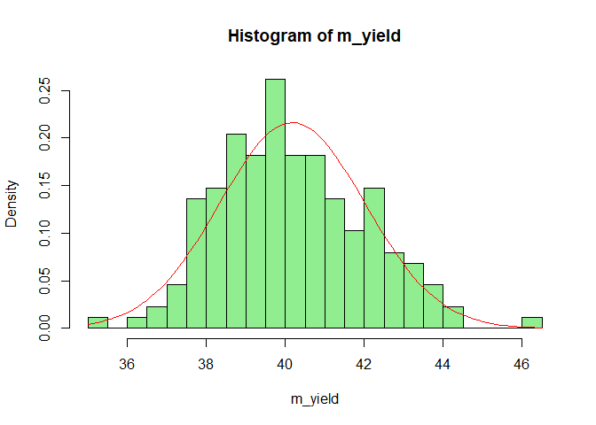

```r
# histogram of yield
hist(m_yield,prob=T,breaks=20,col="lightgreen")
curve(dnorm(x, mean = mean(m_yield), sd = sd(m_yield)), col="red", add=TRUE)
```

#### Tests for normality

```r
#library(olsrr)
ols_test_normality(m_yield)
```

```
## -----------------------------------------------
##        Test             Statistic       pvalue
## -----------------------------------------------
## Shapiro-Wilk              0.9885         0.1647
## Kolmogorov-Smirnov        0.0596         0.5596
## Cramer-von Mises         58.6667         0.0000
## Anderson-Darling          0.7048         0.0647
## -----------------------------------------------
```

Because 3 of 4 normality tests are passed, there will be no need to transform the yield variable.

#### scatterplot of yield

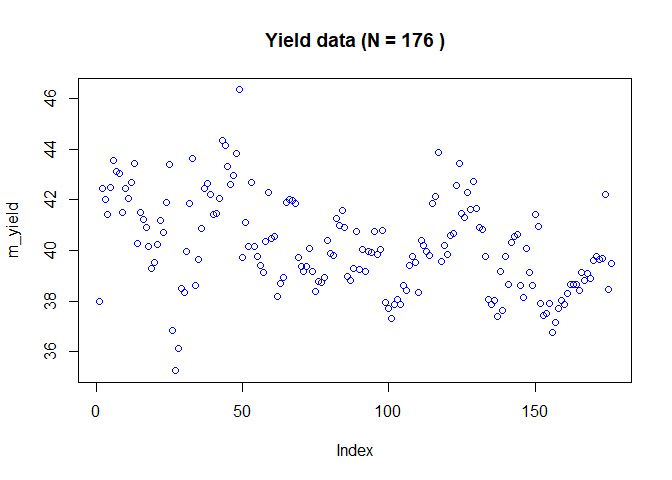

```r
mainlabel=paste("Yield data (N =",nSamples,")")
plot(m_yield,main=mainlabel,col="blue")
```

#### Check for high correlations between columns in the ChemicalManufacturingProcess data set:

#### Correlation grid #1

```r
### be sure to specify corrplot::corrplot because the namespace may be masked by pls::corrplot
#library(corrplot)
correl5 <- cor(m_ChemicalManufacturingProcess)

# determinant is (barely) non-zero
print(paste("Determinant: ", det(correl5)))
```

```
## [1] "Determinant:  -0.0000000000000000000000000000000000000000000000000000000000733930215789486"
```

```r
# some columns are very similar to other columns.
maxcor5 <- round(max(correl5-diag(1,ncol(correl5),ncol(correl5))),5)
mincor5 <- round(min(correl5-diag(1,ncol(correl5),ncol(correl5))),5)
print(paste("Range of off-diag correlations: ",
            paste0("[",mincor5,",",maxcor5,"]"), "on",ncol(correl5),"columns"))
```

```
## [1] "Range of off-diag correlations:  [-0.82847,0.99444] on 58 columns"
```

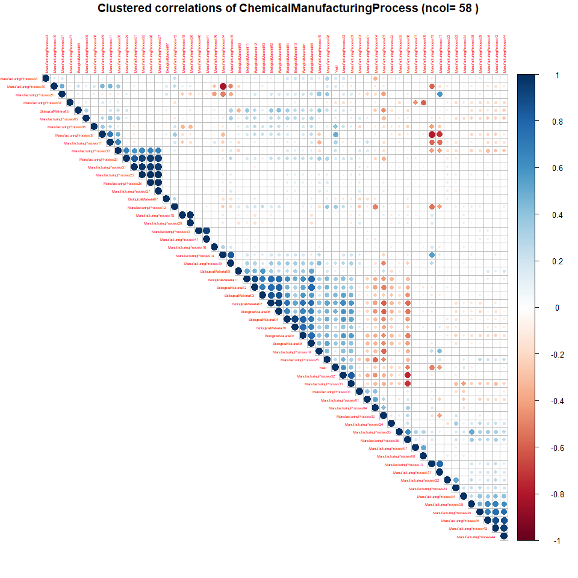

```r
corrplot::corrplot(
  correl5,
  method = "circle",
  type = "upper",
  order = "hclust",
  tl.cex = 0.4,
  main = paste("\nClustered correlations of ChemicalManufacturingProcess (ncol=",
               ncol(correl5),")")
)
```

#### Select high-correlation columns to be dropped

```r
correl6 <- cor(m_predictors)

# determinant is (barely) nonzero
print(paste("Determinant: ", det(correl6)))
```

```
## [1] "Determinant:  -0.000000000000000000000000000000000000000000000000000000000278928584976671"
```

#### Range of correlations

```r
# some columns are very similar to other columns.
maxcor6 <- round(max(correl6-diag(1,ncol(correl6),ncol(correl6))),5)
mincor6 <- round(min(correl6-diag(1,ncol(correl6),ncol(correl6))),5)
print(paste("Range of off-diag predictor correlations: ",
            paste0("[",mincor6,",",maxcor6,"]"), "on",ncol(correl6),"columns"))
```

```
## [1] "Range of off-diag predictor correlations:  [-0.82847,0.99444] on 57 columns"
```

#### eliminate predictor columns which are highly correlated to other predictor columns

```r
cutoff = 0.9
highcorrcols <- findCorrelation(correl6,cutoff = cutoff)
num_highcorrcols <- length(highcorrcols)
print(paste("Quantity of columns which have correlation > ", cutoff, ":",
            num_highcorrcols, "out of",ncol(correl6)))
```

```
## [1] "Quantity of columns which have correlation >  0.9 : 10 out of 57"
```

#### Names of columns to be dropped:

```r
colnames(m_predictors)[highcorrcols] %>% sort()  %>%
  kable(caption = "Columns to be dropped") %>%
  kable_styling(c("bordered","striped"),full_width = F)
```

Columns to be dropped

| x |
| --- |
| BiologicalMaterial02 |
| BiologicalMaterial04 |
| BiologicalMaterial12 |
| ManufacturingProcess18 |
| ManufacturingProcess26 |
| ManufacturingProcess27 |
| ManufacturingProcess29 |
| ManufacturingProcess31 |
| ManufacturingProcess40 |
| ManufacturingProcess42 |

#### Drop above predictors

```r
# drop columns which have high correlation to some other column
m_predictors2 <- m_predictors[,-highcorrcols]
dim(m_predictors2)
```

```
## [1] 176  47
```

```r
print(paste("Remaining number of predictor columns: ", ncol(m_predictors2)))
```

```
## [1] "Remaining number of predictor columns:  47"
```

#### Correlation Plot of reduced predictors

```r
correl7 <- cor(m_predictors2)
# determinant is (barely) nonzero
print(paste("Determinant: ", det(correl7)))
```

```
## [1] "Determinant:  0.0000000000000000000000000000000000000672927803149675"
```

```r
# some columns are very similar to other columns.
maxcor7 <- round(max(correl7-diag(1,ncol(correl7),ncol(correl7))),5)
mincor7 <- round(min(correl7-diag(1,ncol(correl7),ncol(correl7))),5)
print(paste("Range of off-diag correlations: ",
            paste0("[",mincor7,",",maxcor7,"]"), "on",ncol(correl7),"columns"))
```

```
## [1] "Range of off-diag correlations:  [-0.82847,0.87729] on 47 columns"
```

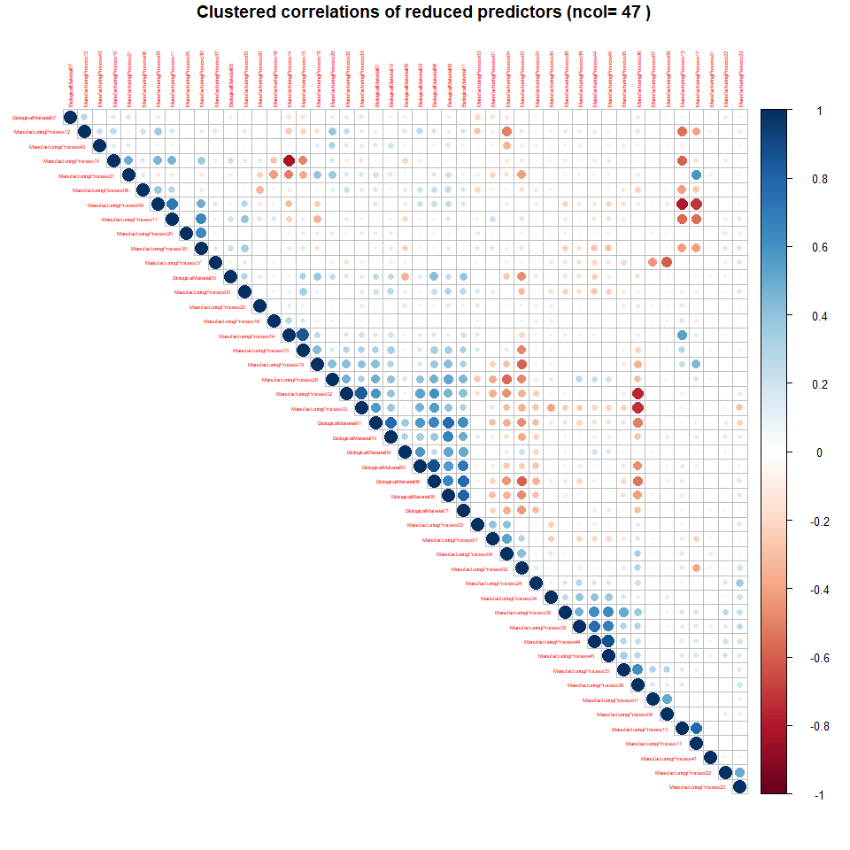

```r
corrplot::corrplot(
  correl7,
  method = "circle",
  type = "upper",
  order = "hclust",
  tl.cex = 0.4,
  main = paste("\nClustered correlations of reduced predictors (ncol=",
               ncol(correl7),")")
)
```

#### Remove Near-Zero Variance predictors

```r
predictors_nearZeroVarCols <- nearZeroVar(m_predictors2)
predictors_nTotalCols <- ncol(m_predictors2)
predictors_nDropCols <- length(predictors_nTotalCols)

print(paste("Number of NearZeroVar columns to be dropped:",
            predictors_nDropCols, "out of", predictors_nTotalCols))
```

```
## [1] "Number of NearZeroVar columns to be dropped: 1 out of 47"
```

```r
colnames(m_predictors2)[predictors_nearZeroVarCols]  %>%
  kable(caption = "Columns to be dropped") %>%
  kable_styling(c("bordered","striped"),full_width = F)
```

Columns to be dropped

| x |
| --- |
| BiologicalMaterial07 |

```r
m_predictors3 <- m_predictors2[,-predictors_nearZeroVarCols]
predictors_nFiltered <- ncol(m_predictors3)
dim(m_predictors3)
```

```
## [1] 176  46
```

### (c) Split the data

#### into a training and a test set,

```r
set.seed(12345)
KJ63trainRow <- createDataPartition(m_yield, p=0.8, list=FALSE)


KJ63predictors.train     <- m_predictors3[KJ63trainRow, ]
KJ63yield.train          <- m_yield[KJ63trainRow, ]
KJ63predictors.test      <- m_predictors3[-KJ63trainRow, ]
KJ63yield.test           <- m_yield[-KJ63trainRow, ]
```

#### pre-process the data,

```r
preProc <- preProcess(KJ63predictors.train,
                      method=c("YeoJohnson","center","scale","knnImpute"))
preProcKJ63predictors.train    <- predict(preProc,KJ63predictors.train)
preProcKJ63predictors.test     <- predict(preProc,KJ63predictors.test)
```

#### tune a model of your choice from this chapter.

```r
set.seed(517)
##ctrl <- trainControl(method = "cv")
KJ63ctrl <- trainControl(method = "boot", number = 25)
plsTune <- train(x          = preProcKJ63predictors.train,
                 y          = KJ63yield.train,
                 method     = "pls",
                 metric     = 'Rsquared',
                 tuneLength = 15,
                 #preProcess = c("YeoJohnson","center","scale"),
                 trControl  = KJ63ctrl)
plsTune
```

```
## Partial Least Squares
##
## 144 samples
##  46 predictor
##
## No pre-processing
## Resampling: Bootstrapped (25 reps)
## Summary of sample sizes: 144, 144, 144, 144, 144, 144, ...
## Resampling results across tuning parameters:
##
##   ncomp  RMSE      Rsquared   MAE
##    1     1.351370  0.4789476  1.088546
##    2     1.281916  0.5354338  1.033149
##    3     1.248938  0.5688726  1.007485
##    4     1.266925  0.5662339  1.013610
##    5     1.317003  0.5466883  1.044936
##    6     1.353998  0.5326223  1.071998
##    7     1.376628  0.5246330  1.096660
##    8     1.394664  0.5180284  1.112775
##    9     1.427052  0.5081854  1.140822
##   10     1.448483  0.5010053  1.154095
##   11     1.468570  0.4950663  1.166082
##   12     1.496297  0.4879506  1.182002
##   13     1.520226  0.4845110  1.191137
##   14     1.544901  0.4810994  1.199692
##   15     1.568391  0.4763670  1.209632
##
## Rsquared was used to select the optimal model using the largest value.
## The final value used for the model was ncomp = 3.
```

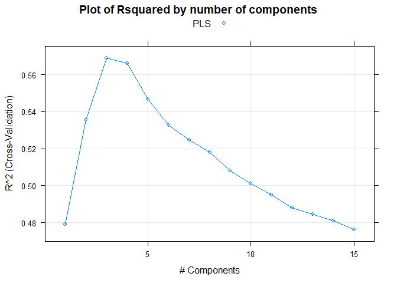

```r
plsResamples <- plsTune$results
plsResamples$Model <- "PLS"

xyplot(Rsquared ~ ncomp,
       data = plsResamples,
       #aspect = 1,
       xlab = "# Components",
       ylab = "R^2 (Cross-Validation)",
       auto.key = list(),
       groups = Model,
       type = c("o", "g"),
       main="Plot of Rsquared by number of components")
```

#### What is the optimal value of the performance metric?

```r
plsTune$bestTune$ncomp
```

```
## [1] 3
```

```r
plsTune$results[rownames(plsTune$bestTune),]
```

```
##   ncomp     RMSE  Rsquared      MAE     RMSESD RsquaredSD      MAESD
## 3     3 1.248938 0.5688726 1.007485 0.08554805 0.06793027 0.08187371
```

The optimal value occurs when the number of components is 3, where $R^2$ = 0.5688726 .

### (d) Predict the response for the test set.

```r
pls_test_predictions <- predict(object = plsTune, newdata = preProcKJ63predictors.test    )
KJ63pls_test_stats <- postResample(pred = pls_test_predictions, obs = KJ63yield.test)
```

#### Plot test data - predicted vs. observed

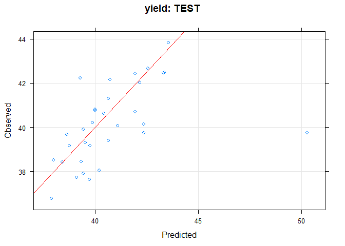

```r
xyplot(KJ63yield.test ~ pls_test_predictions,
## plot the points (type = 'p') and a background grid ('g')
  type = c("p", "g"),
  xlab = "Predicted",
  ylab = "Observed",
  main="yield: TEST",
panel = function(x,y, ...){
  panel.xyplot(x,y, ...)
  panel.abline(a=0,b=1,col="red")
  }
)
```

#### What is the value of the performance metric

```r
(KJ63pls_test_stats <- rbind(KJ63pls_test_stats)) %>%
  kable() %>%
  kable_styling(c("bordered","striped"),full_width = F)
```

|  | RMSE | Rsquared | MAE |
| --- | --- | --- | --- |
| KJ63pls_test_stats | 2.224497 | 0.2241122 | 1.287331 |

#### and how does this compare with the resampled performance metric on the training set?

```r
pls_train_predictions <- predict(object = plsTune) # , newdata = preProcKJ63predictors.train   )
KJ63pls_train_stats <- postResample(pred = pls_train_predictions, obs = KJ63yield.train)
(KJ63pls_train_stats <- rbind(KJ63pls_train_stats)) %>%
  kable() %>%
  kable_styling(c("bordered","striped"),full_width = F)
```

|  | RMSE | Rsquared | MAE |
| --- | --- | --- | --- |
| KJ63pls_train_stats | 1.037505 | 0.6900329 | 0.8429612 |

These are much better than the results on the test set, which suggests that there may be an overfitting problem,or that this model may not be the best choice.

#### Plot TRAINING data - predicted vs. observed

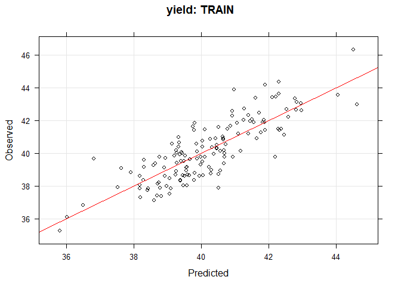

```r
xyplot(KJ63yield.train ~ pls_train_predictions,
## plot the points (type = 'p') and a background grid ('g')
  type = c("p", "g"),
  xlab = "Predicted",
  ylab = "Observed",
  main="yield: TRAIN",
  col="black",
panel = function(x,y, ...){
  panel.xyplot(x,y, ...)
  panel.abline(a=0,b=1,col="red")
  }
)
```

### (e) Importance

#### Which predictors are most important in the model you have trained?

```r
plsImp <- varImp(plsTune, scale = FALSE)
(plsImp)
```

```
## pls variable importance
##
##   only 20 most important variables shown (out of 46)
##
##                        Overall
## ManufacturingProcess32 0.15109
## ManufacturingProcess13 0.13392
## ManufacturingProcess09 0.13193
## ManufacturingProcess17 0.11721
## ManufacturingProcess36 0.11706
## BiologicalMaterial06   0.10225
## BiologicalMaterial08   0.09680
## BiologicalMaterial11   0.09592
## BiologicalMaterial03   0.09516
## ManufacturingProcess06 0.09163
## ManufacturingProcess12 0.08802
## ManufacturingProcess11 0.08690
## BiologicalMaterial01   0.08383
## ManufacturingProcess33 0.08125
## ManufacturingProcess30 0.07039
## ManufacturingProcess28 0.06649
## ManufacturingProcess04 0.05921
## ManufacturingProcess34 0.05914
## BiologicalMaterial10   0.05645
## ManufacturingProcess25 0.05604
```

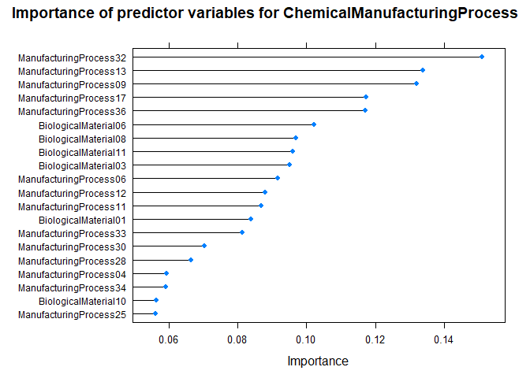

```r
plot(plsImp, top = 20,
     scales = list(y = list(cex = .75)),
     main="Importance of predictor variables for ChemicalManufacturingProcess")
```

#### Do either the biological or process predictors dominate the list?

The Manufacturing Process predictors dominate the list.

### (f) Explore the relationships

#### between each of the top predictors and the response.

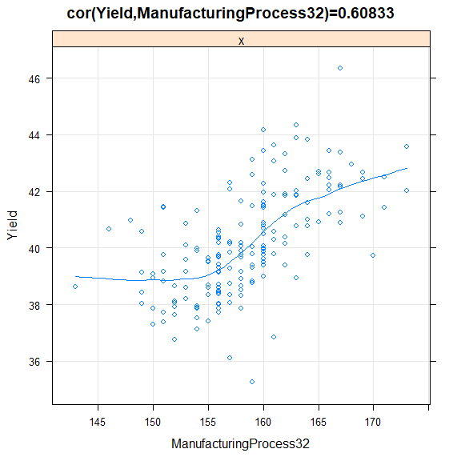

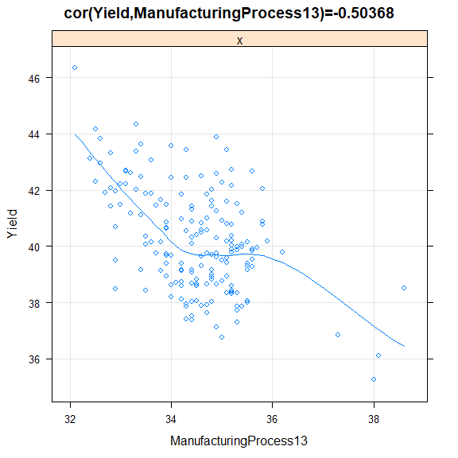

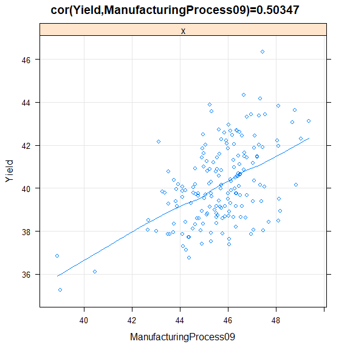

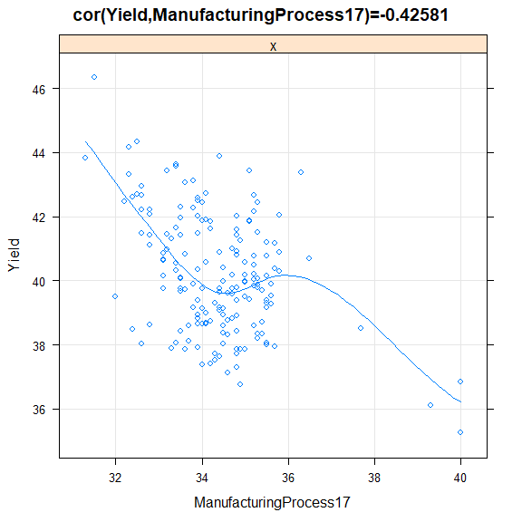

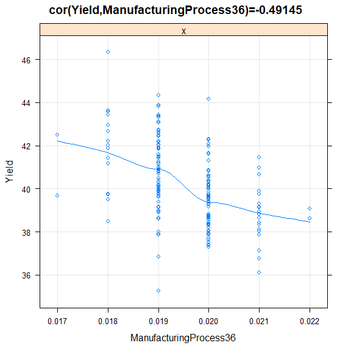

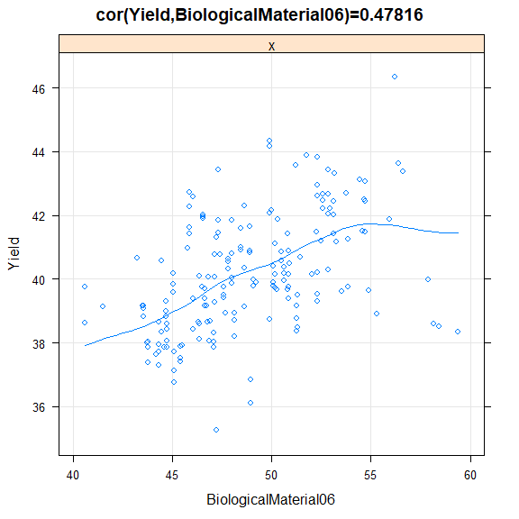

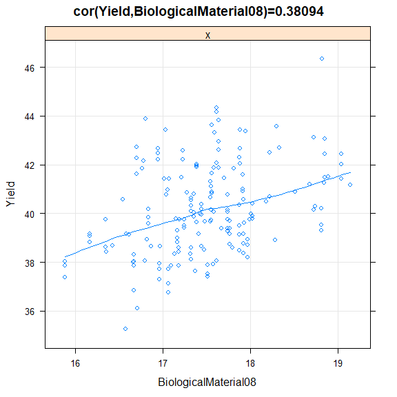

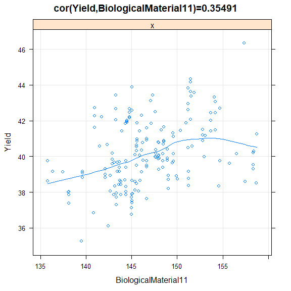

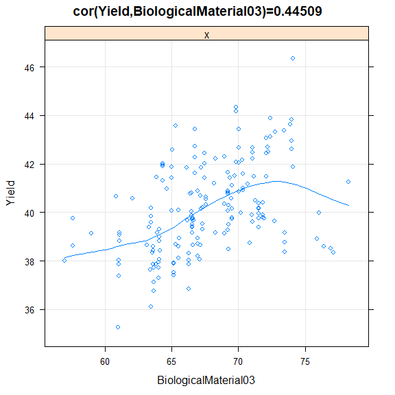

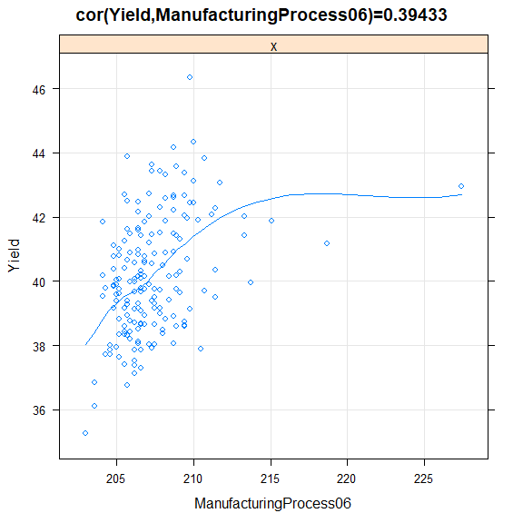

```r
#### Top ten predictors (by "importance")
topnames <- rownames(plsImp[["importance"]])[order(plsImp[["importance"]][["Overall"]],
                                                   decreasing = T)][1:10]

topcor=c()
#### Loop through top ten predictors
for (i in topnames) {
  #print(cor(yield,predictors[i]))
  topcor[i]=cor(yield,predictors[i])
  print(featurePlot(
    x = m_ChemicalManufacturingProcess[, i],
    y = m_ChemicalManufacturingProcess[, 1],
    between = list(x = 1, y = 1),
    type = c("g", "p", "smooth"),
    main=paste0("cor(Yield,",i,")=",round(topcor[i],5)),
    labels=c(i,"Yield")
  ))
}
```

```r
topcor <- as.matrix(topcor)
colnames(topcor) <- "Correlation with yield"


topcor %>%
  kable(caption = "Correlation between yield and most important predictors") %>%
  kable_styling(c("bordered","striped"),full_width = F)
```

Correlation between yield and most important predictors

|  | Correlation with yield |
| --- | --- |
| ManufacturingProcess32 | 0.6083321 |
| ManufacturingProcess13 | -0.5036797 |
| ManufacturingProcess09 | 0.5034705 |
| ManufacturingProcess17 | -0.4258069 |
| ManufacturingProcess36 | -0.4914450 |
| BiologicalMaterial06 | 0.4781634 |
| BiologicalMaterial08 | 0.3809402 |
| BiologicalMaterial11 | 0.3549143 |
| BiologicalMaterial03 | 0.4450860 |
| ManufacturingProcess06 | 0.3943318 |

#### How could this information be helpful in improving yield in future runs of the manufacturing process?

For the `ManufacturingProcess` predictors which display **high positive correlation** with `Yield`, such as 32, 09, and 06, it would be benefical to **increase** usage of such processes, as doing so should cause the yield to increase.

On the other hand, for those `ManufacturingProcess` predictors which display **negative correlation** with `Yield`, such as 13, 17, and 36, it would be beneficial, if possible, to curtail or otherwise **decrease** usage of such processes, as they cause the yield to decrease, so omitting or less reliance on such processes may cause an overall increase in the yield.